# Biostat 203B Homework 2

Due Feb 5 Feb 12 @ 11:59PM

Pablo Geraldo

```r
knitr::opts_chunk$set(echo = TRUE, cache = FALSE, cache.lazy = FALSE)
library(tidyverse)
library(data.table)
library(lubridate)
# Function to create the path to MIMIC data
# If Linux (i.e., in the server), use the local path
# If macOS (i.e., personal laptop), use the box path
os <- sessionInfo()$running
if (str_detect(os, "Linux")) {
  mimic_path <- "/usr/203b-data/mimic-iv"
} else if (str_detect(os, "macOS")) {
  mimic_path <- "/Users/huazhou/Documents/Box Sync/MIMIC/mimic-iv-0.4"
}
```

Use tidyverse (ggpot2, dplyr) to explore the [MIMIC-IV](https://mimic-iv.mit.edu) data introduced in [homework 1](https://ucla-biostat203b-2021winter.github.io/hw/hw1/hw1.html).

```r
# The bash equivalent will be this:
# tree -s -L 2 /Users/huazhou/Documents/Box\ Sync/MIMIC/mimic-iv-0.4
# But here, we use shQuote to avoid going back and forth from bash to R
system(str_c("tree -s -L 2 ", shQuote(mimic_path)), intern = TRUE)
```

```
##  [1] "/usr/203b-data/mimic-iv"
##  [2] "├── [         78]  core"
##  [3] "│   ├── [   17224843]  admissions.csv.gz"
##  [4] "│   ├── [    2884996]  patients.csv.gz"
##  [5] "│   └── [   51188147]  transfers.csv.gz"
##  [6] "├── [       4096]  hosp"
##  [7] "│   ├── [     430049]  d_hcpcs.csv.gz"
##  [8] "│   ├── [   26575586]  diagnoses_icd.csv.gz"
##  [9] "│   ├── [     723633]  d_icd_diagnoses.csv.gz"
## [10] "│   ├── [     564422]  d_icd_procedures.csv.gz"
## [11] "│   ├── [      14845]  d_labitems.csv.gz"
## [12] "│   ├── [   12913088]  drgcodes.csv.gz"
## [13] "│   ├── [  518077567]  emar.csv.gz"
## [14] "│   ├── [  479709397]  emar_detail.csv.gz"
## [15] "│   ├── [    1415469]  hcpcsevents.csv.gz"
```

[output cut: 20 more lines]

## Q1. PhysioNet credential

At this moment, you should already get credentialed on the PhysioNet. Please include a screenshot of your `Data Use Agreement for the MIMIC-IV (v0.4)`.

### Solution

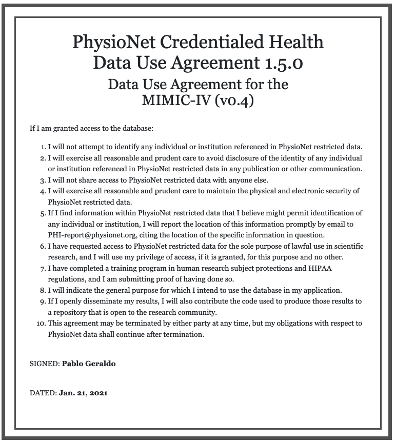

Here is a copy to my credentials to use MIMIC-IV data

## Q2. `read.csv` (base R) vs `read_csv` (tidyverse) vs `fread` (data.table)

There are quite a few utilities in R for reading data files. Let us test the speed of reading a moderate sized compressed csv file, `admissions.csv.gz`, by three programs: `read.csv` in base R, `read_csv` in tidyverse, and `fread` in the popular data.table package. Is there any speed difference? (Hint: R function `system.time` measures runtimes.)

In this homework, we stick to the tidyverse or data.table.

### Solution

Let’s figure out the reading times for the `admissions` file. We will use the `system.time` function to measure how long does it takes for each function to run. To avoid repeating the waiting time when knitting, I am commenting out the functions and pasting the output from each run.

As we can see, the base R function `read.csv` is the slowest one, taking substantially longer to read the data. The tidyverse-based function `read_csv` greatly improves upon the base R version, reading the data around ten times faster. Finally, `data.table::fread` further improves completing the task in around fice seconds. One would expect the difference to be even more substantial for bigger datasets.

**Note**: I tried this several times and of course there is a lot of variation, depending on the load of the server’s memory. There are cases in which the base r version takes even longer, and cases in which `read_csv` and `fread` are not that different. So this is not a formal benchmarking.

```r
# First, use the native read.csv
read.csv(paste0(mimic_path,"/core/admissions.csv.gz")) %>%
  system.time()
```

```
##    user  system elapsed
##  63.222   0.395 102.495
```

```r
# Second, use tidyverse read_csv
read_csv(paste0(mimic_path,"/core/admissions.csv.gz")) %>%
  system.time()
```

```
##    user  system elapsed
##   6.243   0.321  11.084
```

```r
# Finally, use data.table fread function
fread(paste0(mimic_path,"/core/admissions.csv.gz")) %>%
  system.time()
```

```
##    user  system elapsed
##   2.549   0.172   3.914
```

## Q3. ICU stays

`icustays.csv.gz` (https://mimic-iv.mit.edu/docs/datasets/icu/icustays/) contains data about Intensive Care Units (ICU) stays. Summarize following variables using appropriate numerics or graphs:

- how many unique `stay_id`?
- how many unique `subject_id`?

### Solution

To answer those questions, I will use the following code. Basically, this is subsetting the data to the list of unique ids, and then counting the length of the resulting vector.

```r
# First, let's read the data
icustays <-
  fread(paste0(mimic_path,"/icu/icustays.csv.gz"))

# Unique stay_id
# Notice that the number of unique stay_id
# is the same as the rows in the data
# nrow(icustays)
length(unique(icustays$stay_id))
```

```
## [1] 69619
```

```r
# Unique subject_id
length(unique(icustays$subject_id))
```

```
## [1] 50048
```

We can see that there are 69619 unique `stay_id` and 50048 unique `stay_id` in the data.

- length of ICU stay

For this question, it is probably more convenient to graph the data and explore the overall distribution of the stays in the ICU, instead of providing a single numerical summary. We will need to create the variable for the length of stay.

I tried several options, but due to very large outliers the best option seems to be transforming stay to the log scale, and using either a boxplot or an histogram:

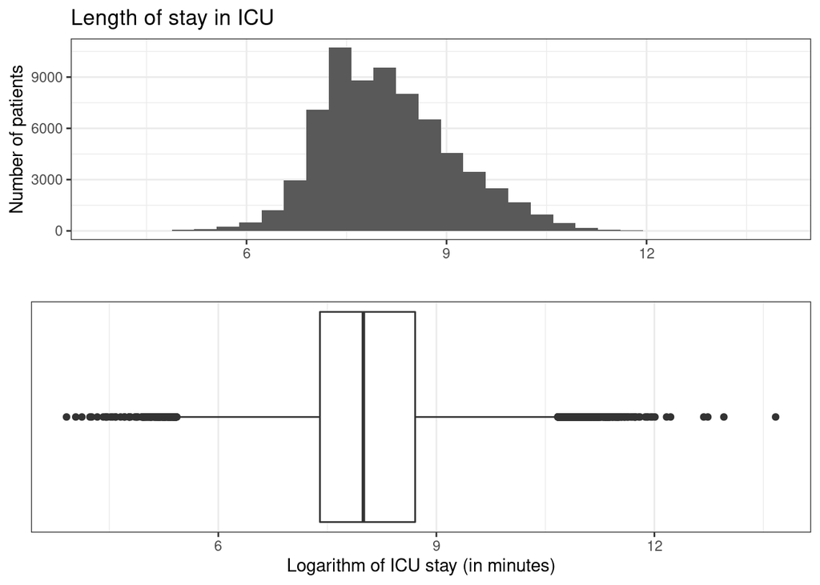

```r
# Create the staytime variable
# If I use the function lubridate::as_date
# The resulting is a "difftime" variable type
# Measured in numbers of days
# Here I use lubridate::ymd_hms
# Measured in minutes
# So the plot is more precise and looks better
icustays <- icustays %>%
  mutate(staytime = ymd_hms(outtime) - ymd_hms(intime),
         # Bc log is not defined by difftime
         staydays = as.numeric(staytime),
         # Take log for better plotting
         staylog = log(staydays))

# Load the gridExtra library
# To overlay the histogram and boxplot
suppressMessages(library(gridExtra))

# First, create the histogram
stay_hist <- icustays %>%
  ggplot(aes(x = staylog)) +
  # Can use ..density.. instead
  geom_histogram(aes(y = ..count..)) +
  labs(title = "Length of stay in ICU",
       x = "",
       y = "Number of patients",
       fill = "Care unit") +
  scale_x_continuous(breaks=seq(3, 15, by = 3)) +
  theme_bw()

# Then, create the boxplot
stay_box <- icustays %>%
  ggplot(aes(x = staylog)) +
  geom_boxplot() +
  labs(y = "",
       x = "Logarithm of ICU stay (in minutes)") +
  scale_x_continuous(breaks = seq(3, 15, by = 3)) +
  scale_y_continuous(breaks = NULL) +
  theme_bw()

# Finally, combine both plots
grid.arrange(stay_hist, stay_box, nrow = 2)
```

- first ICU unit

For this question, I will use colored barplots with their respective labels identifying different care units. We can see that the most common entrance unit is the Medical Intensive Care Unit, followed by Medical/Surgical, Cardiac, and Surgical Intensive Care Unit. Basically, the vast majority of first ICU units are from a combination of Medical/Surgical units.

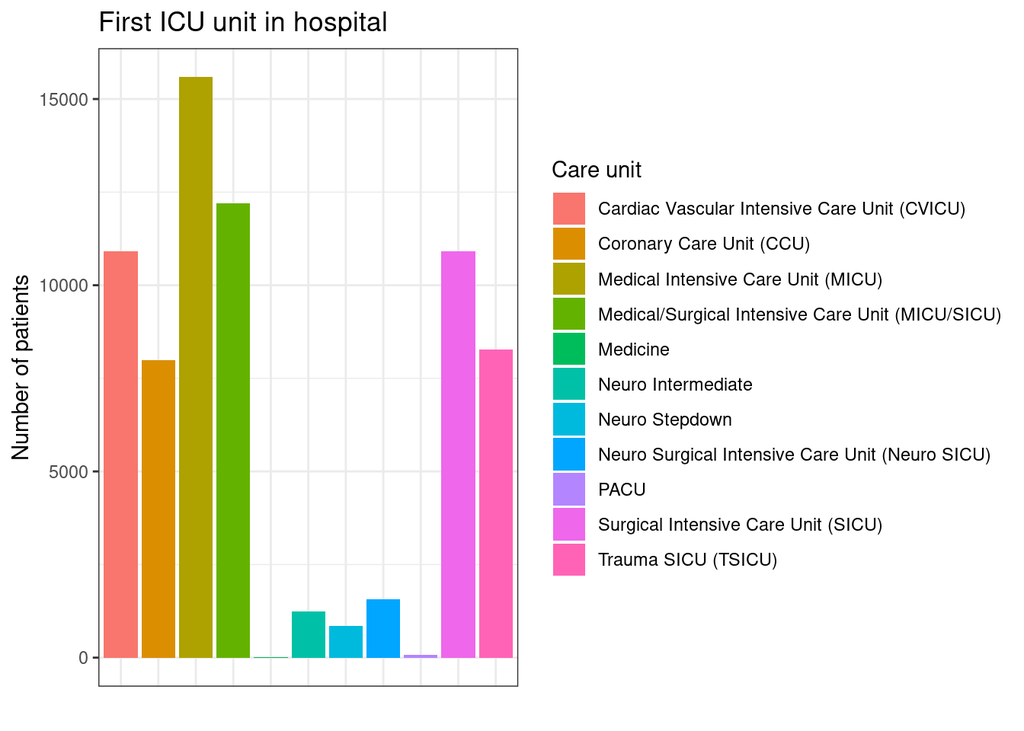

```r
icustays %>%
  ggplot(aes(x = first_careunit)) +
  geom_bar(aes(fill = first_careunit)) +
  labs(title = "First ICU unit in hospital",
       x = "", y = "Number of patients",
       fill = "Care unit") +
  theme_bw() +
  # Remove x axis to avoid repeating the labels
  theme(axis.text.x = element_blank(),
        axis.ticks.x = element_blank())
```

```r
# This code would help to display the labels
# On the x axis
# But I remove it because it is redundant
#  theme(axis.text.x =
#          element_text(angle = 90, vjust = 0.5, hjust = 1))
```

- last ICU unit

Here I follow the same approach as above. The results are very similar, and we observe that Medical Intensive Care Unit is once again the most common last ICU unit, followed by Medical/Surgical, Cardiac, and Surgical Intensive Care Unit.

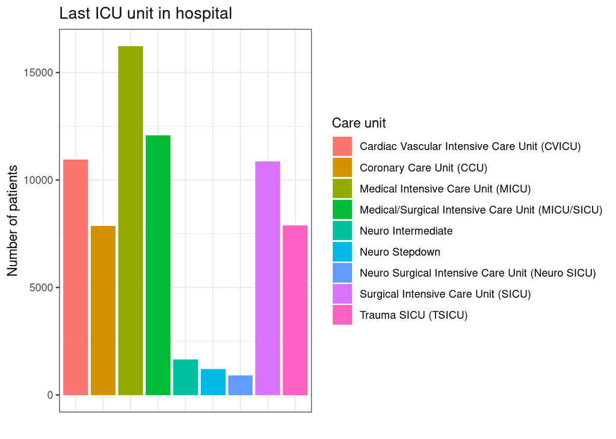

```r
icustays %>%
  ggplot(aes(x = last_careunit)) +
  geom_bar(aes(fill = last_careunit)) +
  labs(title = "Last ICU unit in hospital",
       x = "", y = "Number of patients",
       fill = "Care unit") +
  theme_bw() +
  theme(axis.text.x = element_blank(),
        axis.ticks.x = element_blank())
```

## Q4. `admission` data

Information of the patients admitted into hospital is available in `admissions.csv.gz`. See https://mimic-iv.mit.edu/docs/datasets/core/admissions/ for details of each field in this file. Summarize following variables using appropriate graphs. Explain any patterns you observe.

Note it is possible that one patient (uniquely identified by the `subject_id`) is admitted into hospital multiple times. When summarizing some demographic information, it makes sense to summarize based on unique patients.

### Solution

First, let’s read the data and save it to the object `admissions`. We can see that there are 524,520 rows and 15 columns.

```r
admissions <-
  fread(paste0(mimic_path,"/core/admissions.csv.gz"))
# dim(admissions)
# 524,520 x 15
```

- Admission year

Let’s start describing the admission year variable. We would need to extract the year from the `admittime` variable. Also notice that the resulting year is masked, so to convert it back to (a range of) actual years one would need to use the `anchor_year` variable that is not in this but in the `patients` dataset, so I will describe the admissions using the masked year. Finally, I am not filtering unique id’s because this is not demographic data.

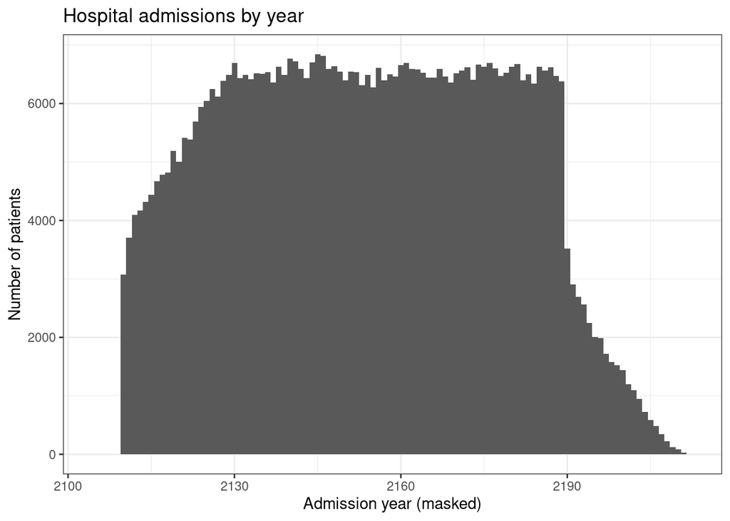

```r
admissions %>%
  # If we want to keep only one admission per patient
  # We need to filter by unique ids, use:
  # distinct(subject_id, .keep_all = TRUE) %>%
  # Alternatively:
  # filter(subject_id %in% unique(subject_id)) %>%
  mutate(admit_year = lubridate::year(admittime)) %>%
  ggplot(aes(x = admit_year)) +
  geom_histogram(binwidth = 1) +
  labs(title = "Hospital admissions by year",
       x = "Admission year (masked)",
       y = "Number of patients") +
  theme_bw()
```

We can see a somewhat curious pattern: a very regular number of admissions per year in the middle block, and a steady increase (and decrease) in earlier (later) years. This pattern is probably due to the way in which years are masked (truncated at both extremes)

- Admission month

Based on the plot below, we can see that in general admissions are very homogeneous across months, with the sole exception of February, as expected. This is most likely due to the shorter length of the month, since the gap is proportional to the 1-3 days missing.

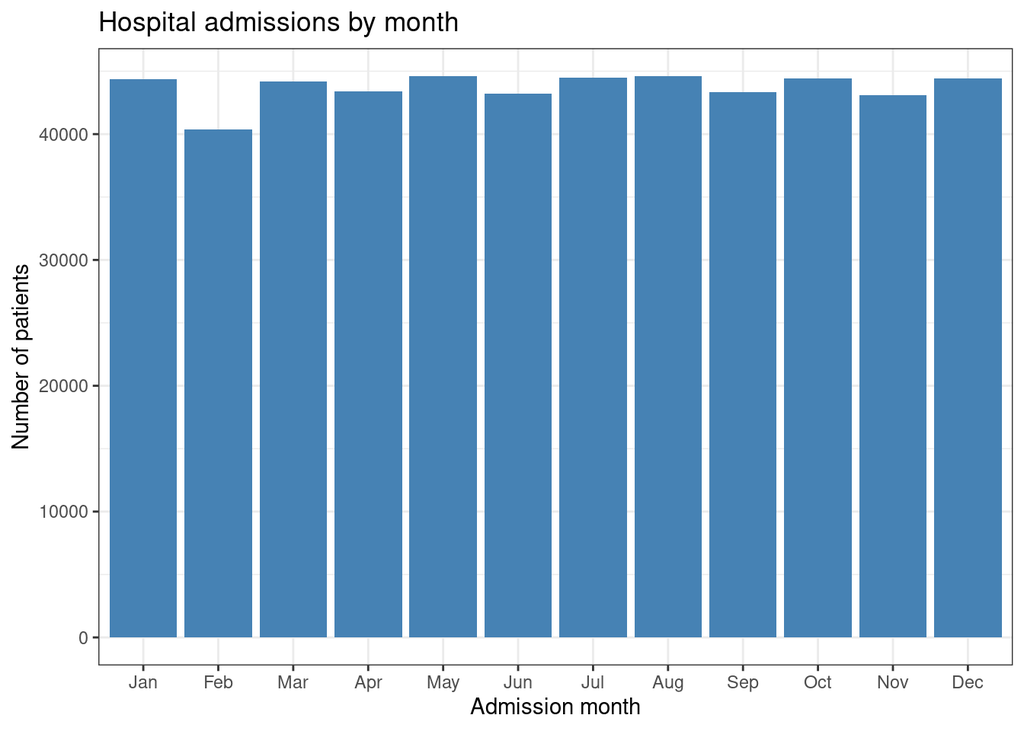

```r
admissions %>%
  mutate(admit_month =
           # label = TRUE for month labels
           # instead of numbers
           lubridate::month(admittime, label = TRUE)) %>%
  ggplot(aes(x = admit_month)) +
  geom_bar(fill = "steelblue") +
  labs(title = "Hospital admissions by month",
       x = "Admission month",
       y = "Number of patients") +
  theme_bw()
```

- Admission month day

Days of admissions seem to be very homogeneous over the month too, with a noticeable drop in days 29-31. Most likely this is just a product of the varying number of days per month.

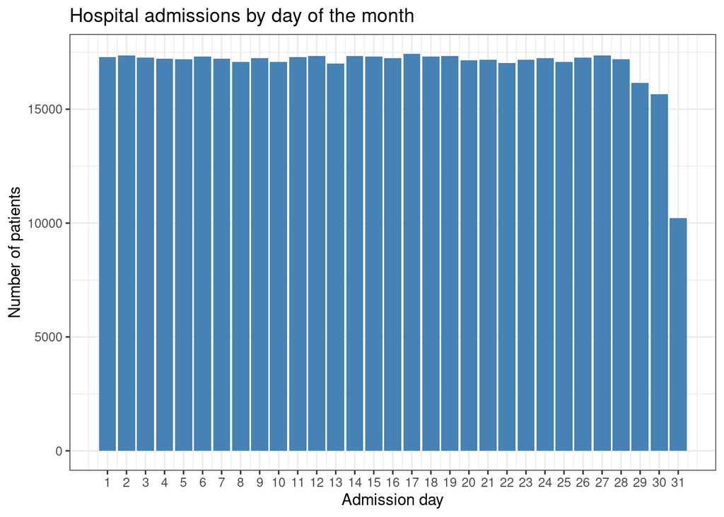

```r
admissions %>%
  mutate(admit_day =
           lubridate::day(admittime)) %>%
  ggplot(aes(x = admit_day)) +
  geom_bar(fill = "steelblue") +
  labs(title = "Hospital admissions by day of the month",
       x = "Admission day",
       y = "Number of patients") +
  scale_x_continuous(breaks = c(1:31)) +
  theme_bw()
```

- Admission week day

According to the plot, admissions do not vary a lot by different weekdays, with the sole noticeable although small bump on Saturdays (maybe more accidents? I can’t tell).

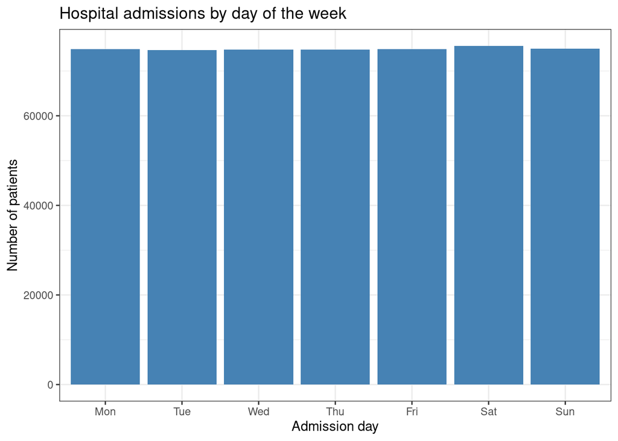

```r
admissions %>%
  mutate(admit_wday =
           # label = TRUE for day labels
           # week_start = 1 for Monday (default Sunday)
           lubridate::wday(admittime,
                           label = TRUE, week_start = 1)) %>%
  ggplot(aes(x = admit_wday)) +
  geom_bar(fill = "steelblue") +
  labs(title = "Hospital admissions by day of the week",
       x = "Admission day",
       y = "Number of patients") +
  theme_bw()
```

- Admission hour (anything unusual?)

The distribution of admissions across hour of the day is really curious. It is trimodal, with the absolute peak at 12am, a second peak at 7am, and then a steady increase from the morning to 6pm. My guess would be that this roughly coincide with personnel shifts, but I can’t tell for sure.

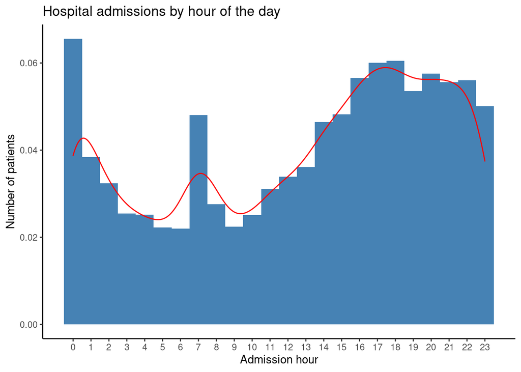

```r
admissions %>%
  mutate(admit_hour =
           lubridate::hour(admittime)) %>%
  ggplot(aes(x = admit_hour, y = ..density..)) +
  geom_histogram(binwidth = 1, fill = "steelblue") +
  # Overlay a density curve
  # adjust calibrates the bandwith
  geom_density(color = "red", adjust = 2) +
  labs(title = "Hospital admissions by hour of the day",
       x = "Admission hour",
       y = "Number of patients") +
  scale_x_continuous(breaks = c(0:23)) +
  theme_classic()
```

- Number of deaths in each year

Here we see a pattern pretty similar to the admissions by year. In general, deaths follow the same trend as admissions (probably for the same reasons discussed above), but obviously deaths are a small fraction of total admissions. In other words, this means that (happily!) most people leave the hospital alive.

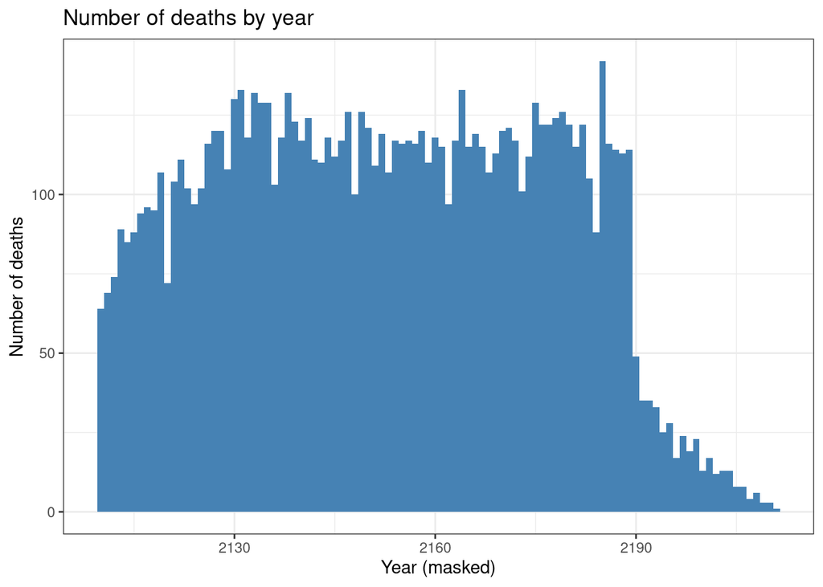

```r
admissions %>%
  # First, filter out non-deaths
  # Stored as empty strings
  filter(deathtime != "") %>%
  # Now we can convert to date
  mutate(death_year =
           lubridate::year(deathtime)) %>%
  ggplot(aes(x = death_year)) +
  geom_histogram(binwidth = 1, fill = "steelblue") +
  labs(title = "Number of deaths by year",
       x = "Year (masked)",
       y = "Number of deaths") +
  theme_bw()
```

- Admission type

Admission type is largely dominated by emergency admissions through emergency ward (EW). The less common correspond to ambulatory observation visits.

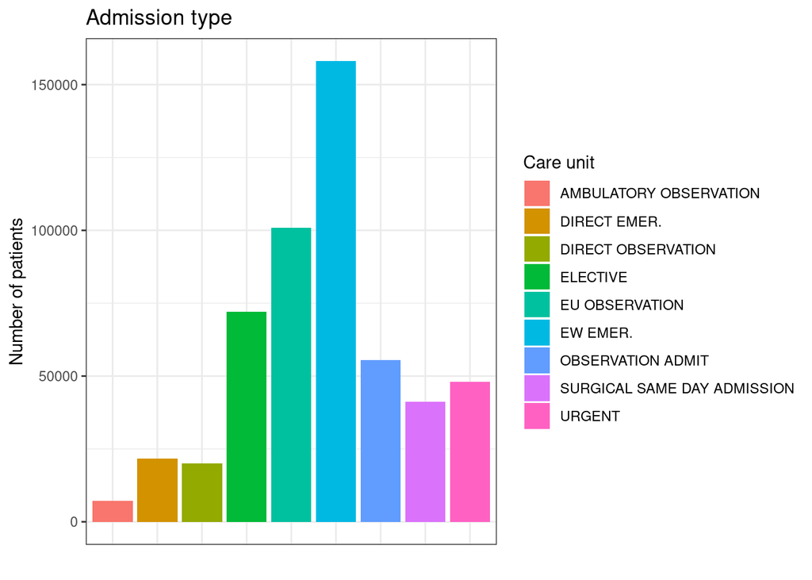

```r
admissions %>%
  ggplot(aes(x = admission_type)) +
  geom_bar(aes(fill = admission_type)) +
  labs(title = "Admission type",
       x = "", y = "Number of patients",
       fill = "Care unit") +
  theme_bw() +
  theme(axis.text.x = element_blank(),
        axis.ticks.x = element_blank())
```

- Number of admissions per patient

This is a highly skewed distribution, with most patients concentrated in the lower end, but a few patients with extremely large number of admissions (up to 238). I used histogram to show this extreme skewness, because even boxplots get too affected by the outliers (and using a different scale, like log-transforming the data, does not make a lot of sense here).

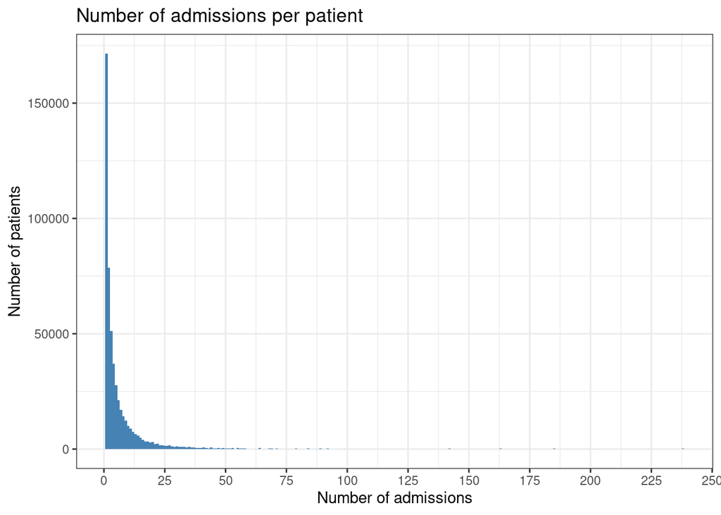

```r
admissions %>%
  # First, group by patient
  group_by(subject_id) %>%
  # Then, count the number of admissions
  mutate(admit_num = n()) %>%
  ungroup() %>%
  # summarise(max(admit_num)) # 238 times!
  # Then plot
  ggplot(aes(x = admit_num)) +
  geom_histogram(fill = "steelblue", binwidth = 1) +
  # geom_boxplot() +
  labs(title = "Number of admissions per patient",
       x = "Number of admissions",
       y = "Number of patients") +
  scale_x_continuous(breaks = seq(0, 250, by=25)) +
  theme_bw()
```

- Admission location

Emergency room is by far the most common admission location, followed by “Physician Referral”. There is also a sizable amount of admissions with missing location (empty).

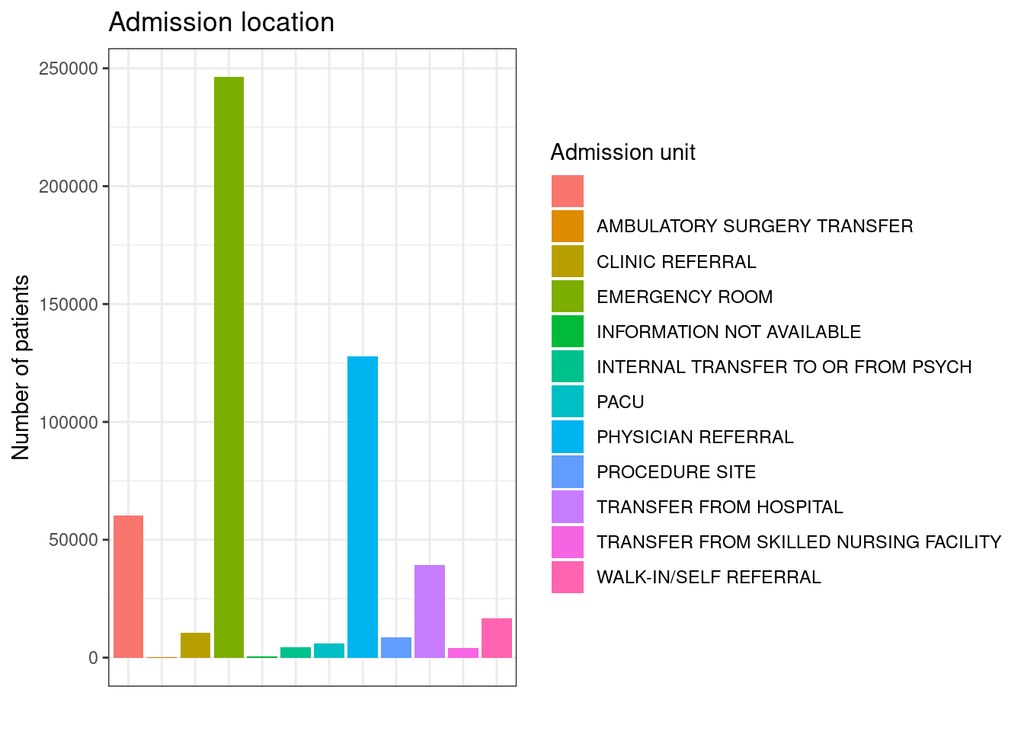

```r
admissions %>%
  ggplot(aes(x = admission_location)) +
  geom_bar(aes(fill = admission_location)) +
  labs(title = "Admission location",
       x = "", y = "Number of patients",
       fill = "Admission unit") +
  theme_bw() +
  theme(axis.text.x = element_blank(),
        axis.ticks.x = element_blank())
```

- Discharge location

In terms of discharge location, most of the patients are sent home, followed by those sent home under medical care. In the discharge data there is also a sizeble amount of missing information (second largest category).

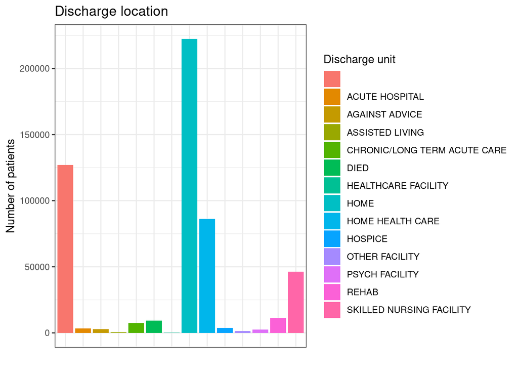

```r
admissions %>%
  ggplot(aes(x = discharge_location)) +
  geom_bar(aes(fill = discharge_location)) +
  labs(title = "Discharge location",
       x = "", y = "Number of patients",
       fill = "Discharge unit") +
  theme_bw() +
  theme(axis.text.x = element_blank(),
        axis.ticks.x = element_blank())
```

- Insurance

For this question, I am assuming that insurance is a time-invariante individual characteristic, which is not necessarily realistic (in fact, they *do* vary, as specified in the documentation) but this strategy is preferably when analyzing the composition of the hospitalized patients over time to prevent counting multiple times patients with multiple admissions. So I am keeping only one admission per patient (N = 257,366).

Among those patients, we can see that almost 10% have Medicaid, slightly more than 20% have Medicare, while the remaining 70% have other type of insurance. It is unclear if the “Other” category includes uninsured, but this is likely.

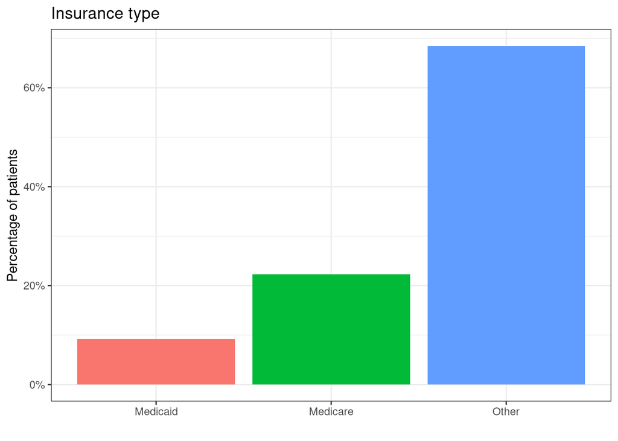

```r
admissions_first <-
  admissions %>%
  # Format as date, then numeric
  # The second step is not necessary
  # But is faster than work on dates
  mutate(admit = as.numeric(as_date(admittime))) %>%
  group_by(subject_id) %>%
  # Select the first date
  # Break ties keeping the first appearance
  slice_min(admit, with_ties = FALSE) %>%
  ungroup()

# Plot the distribution by insurances
admissions_first %>%
  # Yaxis: Insurance/N
  ggplot(aes(x = insurance, y = (..count..)/sum(..count..))) +
  geom_bar(aes(fill = insurance)) +
  labs(title = "Insurance type",
       x = "", y = "Percentage of patients") +
  theme_bw() +
  # Remove fill legend
  theme(legend.position = "none") +
  # Scale Yaxis as percentages
  scale_y_continuous(labels = scales::percent)
```

- Language

The language variable is not very specific, listing only if the patient speaks English or not (?). More than 90% of the patients are English speakers according to these data.

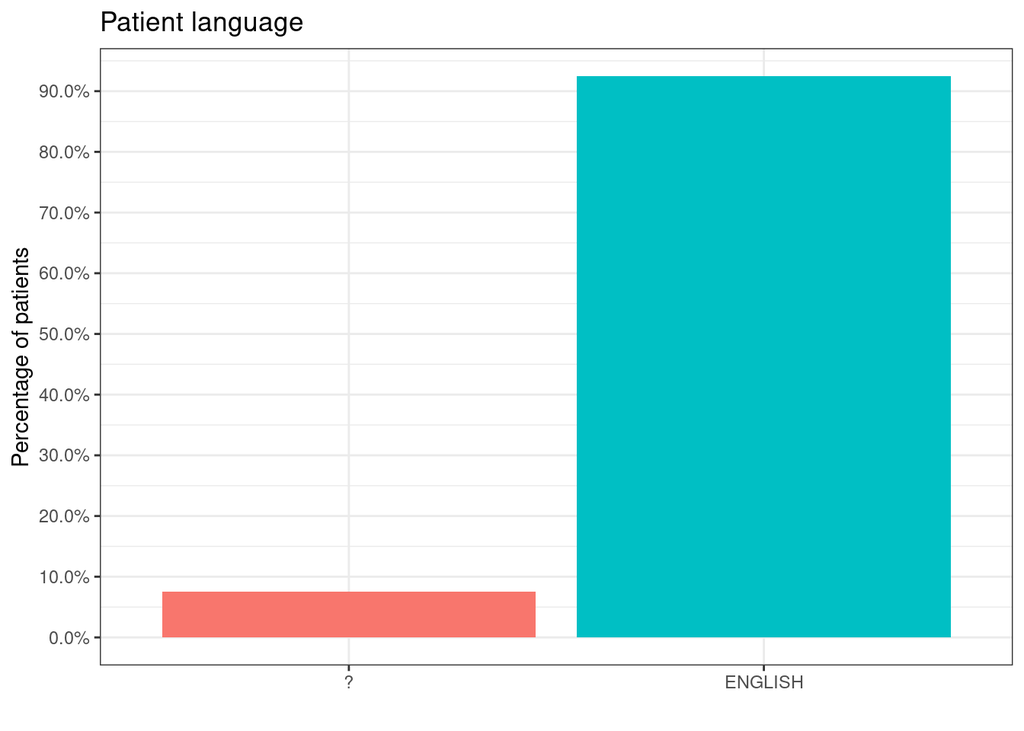

```r
# Plot the distribution of language
admissions_first %>%
  # Yaxis: Language/N
  ggplot(aes(x = language, y = (..count..)/sum(..count..))) +
  geom_bar(aes(fill = language)) +
  labs(title = "Patient language",
       x = "", y = "Percentage of patients") +
  theme_bw() +
  # Remove fill legend
  theme(legend.position = "none") +
  # Scale Yaxis as percentages
  scale_y_continuous(breaks = seq(0, 1, by = 0.1),
                     labels = scales::percent)
```

- Martial status

Married is the most prevalent category, followed closely by Single, each representing approximately a third of the data. Around 25% of the patients do not have any information regarding their marital status. Smaller fractions correspond to either Widowed or Divorced.

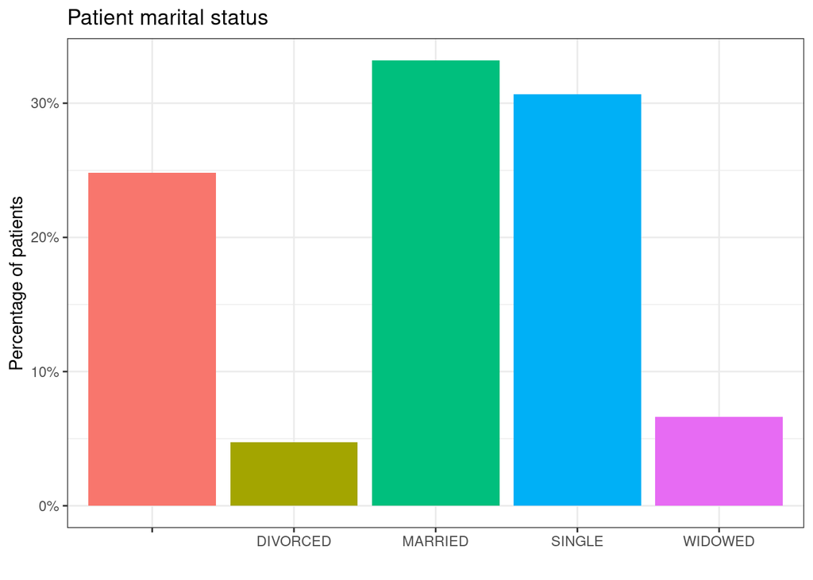

```r
# Plot the distribution of marital status
admissions_first %>%
  # Yaxis: status/N
  ggplot(aes(x = marital_status, y = (..count..)/sum(..count..))) +
  geom_bar(aes(fill = marital_status)) +
  labs(title = "Patient marital status",
       x = "", y = "Percentage of patients") +
  theme_bw() +
  # Remove fill legend
  theme(legend.position = "none") +
  # Scale Yaxis as percentages
  scale_y_continuous(breaks = seq(0, 1, by = 0.1),
                     labels = scales::percent)
```

- Ethnicity

The ethnicity data show us that White is by far the most prevalent ethnicity in the hospital admissions, representing more thna 60%. Close to 12% is the second largest group, Black/African American. Almost 10% is unavailable (Unable to obtain plus unknown), while Asian and Hispanic/Latino represent more than 5% each.

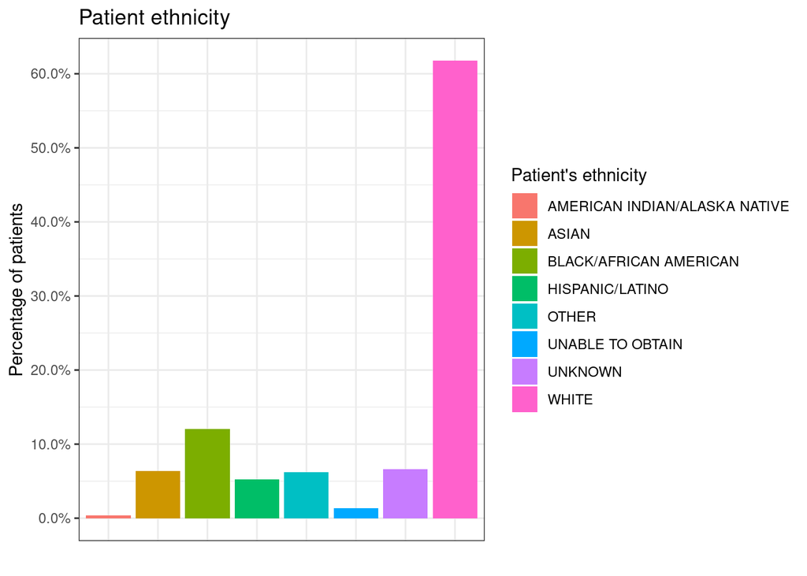

```r
# Plot the distribution of ethnicity
admissions_first %>%
  # Yaxis: Ethnicity/N
  ggplot(aes(x = ethnicity, y = (..count..)/sum(..count..))) +
  geom_bar(aes(fill = ethnicity)) +
  labs(title = "Patient ethnicity",
       x = "", y = "Percentage of patients",
       fill = "Patient's ethnicity") +
  theme_bw() +
  # Scale Yaxis as percentages
  scale_y_continuous(breaks = seq(0, 1, by = 0.1),
                     labels = scales::percent) +
  theme(axis.text.x = element_blank(),
        axis.ticks.x = element_blank())
```

- Death

Here I will do a similar filtering than above, to keep only one observation per patient, but instead of keeping the first, I am keeping the last hospital admission. The logic is that, if a patient with multiple registered visits to the hospital dies, it should has been on their last visit.

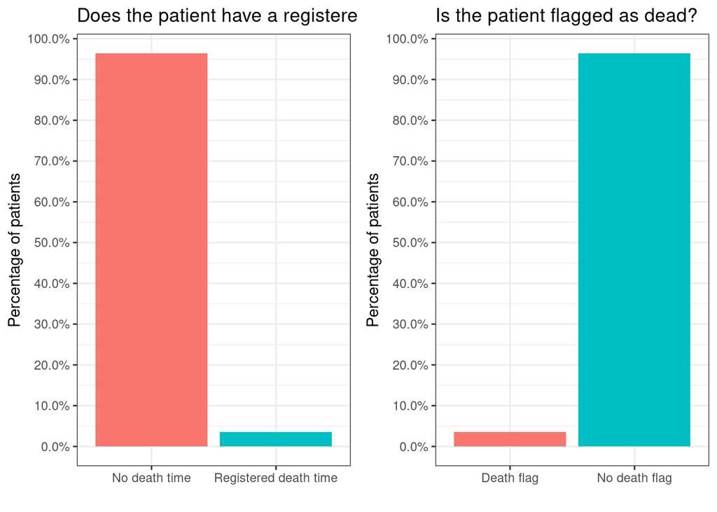

```r
# I will overwrite the admissions object
# To avoid duplicating and save some memory
admissions_last <-
  admissions %>%
  # Format as date, then numeric
  # The second step is not necessary
  # But is faster than work on dates
  mutate(admit = as.numeric(as_date(admittime))) %>%
  group_by(subject_id) %>%
  # Select the last date
  # Break ties keeping the last appearance
  slice_max(admit, with_ties = FALSE) %>%
  ungroup()

# Plot the percentage death
# Comparing flag and deathtime
deathtime_bar <-
  admissions_last %>%
  # Create death indicator
  mutate(death_indicator =
           ifelse(deathtime == "",
                  "No death time", "Registered death time")) %>%
  # Yaxis: Death/N
  ggplot(aes(x = death_indicator, y = (..count..)/sum(..count..))) +
  geom_bar(aes(fill = death_indicator)) +
  labs(title = "Does the patient have a registered death time?",
       x = "", y = "Percentage of patients") +
  theme_bw() +
  # Scale Yaxis as percentages
  scale_y_continuous(breaks = seq(0, 1, by = 0.1),
                     labels = scales::percent) +
  theme(legend.position = "none")

deathflag_bar <-
  admissions_last %>%
  mutate(death_flag =
           ifelse(hospital_expire_flag == 0,
                  "No death flag", "Death flag")) %>%
  # Yaxis: Death/N
  ggplot(aes(x = death_flag, y = (..count..)/sum(..count..))) +
  geom_bar(aes(fill = death_flag)) +
  labs(title = "Is the patient flagged as dead?",
       x = "", y = "Percentage of patients") +
  theme_bw() +
  # Scale Yaxis as percentages
  scale_y_continuous(breaks = seq(0, 1, by = 0.1),
                     labels = scales::percent) +
  theme(legend.position = "none")

# Finally, combine both plots
grid.arrange(deathtime_bar, deathflag_bar, nrow = 1)
```

We can finally describe the percentage of deaths among last hospitalization over the years. We can see that the percentage of people dying during hospitalization moves between 2.5 and 7.5%, and it seems to be an upward trend. The drop at the end is probably explained by the truncation of the masked years.

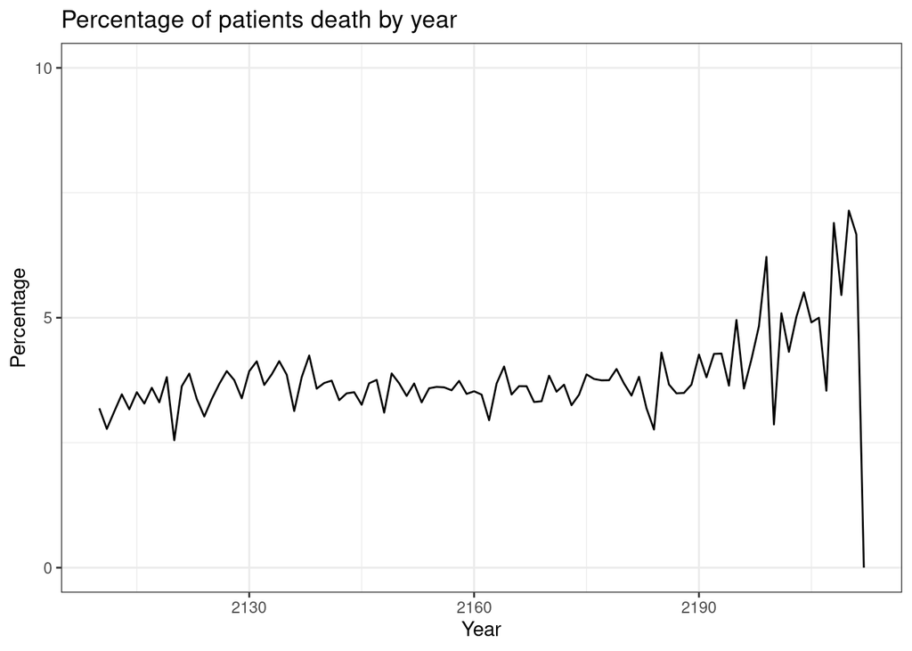

```r
admissions_last %>%
  mutate(admityear = lubridate::year(admittime)) %>%
  group_by(admityear) %>%
  summarise(nyear = n(),
            ndeath = sum(hospital_expire_flag),
            pdeath = ndeath/nyear*100) %>%
  ggplot(aes(x = admityear, y = pdeath)) +
  geom_line() +
  labs(title = "Percentage of patients death by year",
       x = "Year", y = "Percentage") +
  theme_bw() +
  scale_y_continuous(breaks = seq(0, 100, by = 5),
                     limits = c(0,10)) +
  theme(legend.position = "none")
```

## Q5. `patient` data

Explore `patients.csv.gz` (https://mimic-iv.mit.edu/docs/datasets/core/patients/) and summarize following variables using appropriate numerics and graphs:

### Solution

```r
# First, let's read the data
patients <-
  fread(paste0(mimic_path,"/core/patients.csv.gz"))
dim(patients)
```

```
## [1] 383220      6
```

```r
names(patients)
```

```
## [1] "subject_id"        "gender"            "anchor_age"
## [4] "anchor_year"       "anchor_year_group" "dod"
```

We can see that, in the patient data, there are 383,220 observations and 6 variables.

- Exploring `gender` variable

According to the graph, there is slightly more women than men in hospitals, a difference of around 5%.

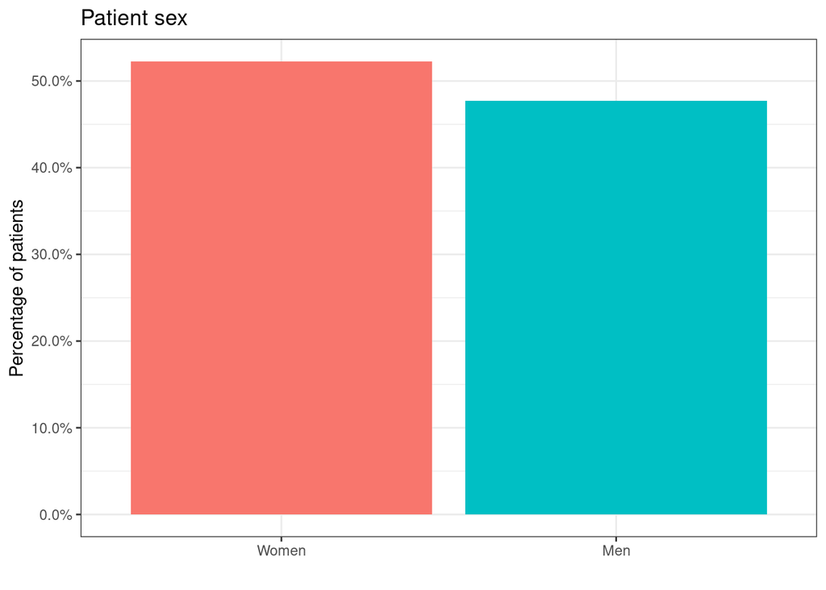

```r
# Plot the distribution of gender
patients %>%
  # Yaxis: gender/N
  ggplot(aes(x = gender, y = (..count..)/sum(..count..))) +
  geom_bar(aes(fill = gender)) +
  # I'm labelling as patient sex instead of gender
  # Based on the code book
  labs(title = "Patient sex",
       x = "", y = "Percentage of patients") +
  theme_bw() +
  # Remove fill legend
  theme(legend.position = "none") +
  # Scale Yaxis as percentages
  scale_y_continuous(breaks = seq(0, 1, by = 0.1),
                     labels = scales::percent) +
  scale_x_discrete(labels = c("Women", "Men"))
```

- Exploring `anchor_age` variable

When exploring the variable anchor_age, there is a lot of 0s. It is hard to believe that those are true zeroes, most likely they are due to coding errors or missing values registered as 0. So in the analysis below I am filtering out those cases.

The resulting distribution of age is bimodal, with most cases in the early 20s, and then a second peak in the mid 50s. As expected, there is a long right tail of older ages.

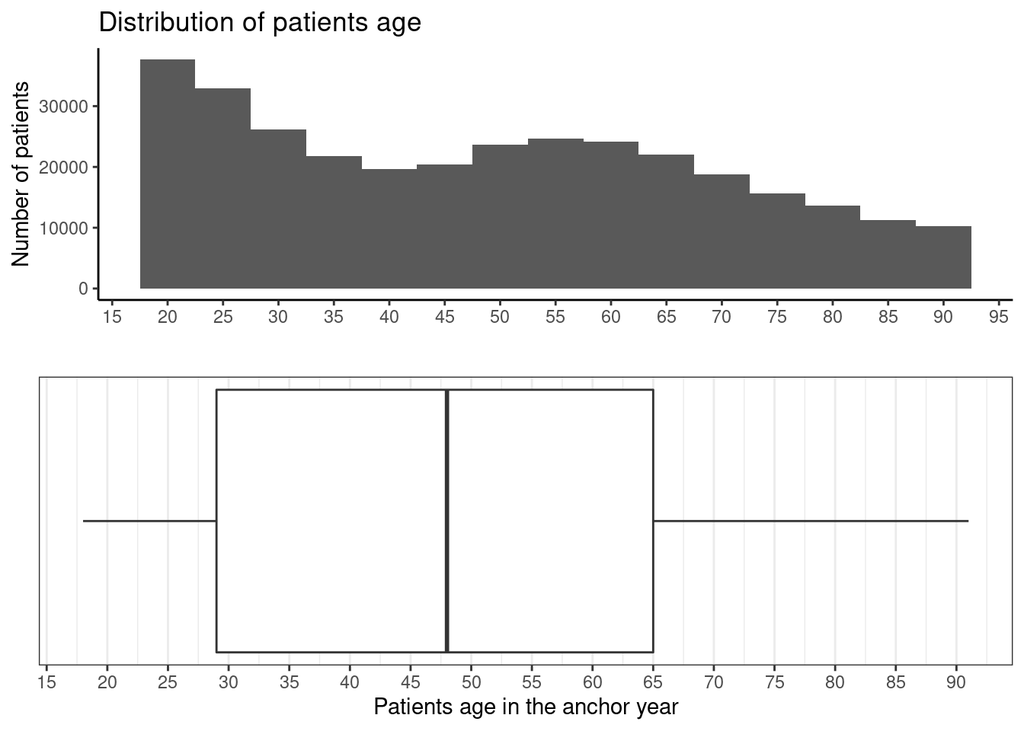

```r
# First, create the histogram
age_hist <- patients %>%
  filter(anchor_age != 0) %>%
  ggplot(aes(x = anchor_age)) +
  # Can use ..density.. instead
  geom_histogram(aes(y = ..count..), binwidth = 5) +
  labs(title = "Distribution of patients age",
       x = "",
       y = "Number of patients") +
  scale_x_continuous(breaks=seq(0, 100, by = 5)) +
  theme_classic()

# Then, create the boxplot
age_box <- patients %>%
  filter(anchor_age != 0) %>%
  ggplot(aes(x = anchor_age)) +
  geom_boxplot() +
  labs(y = "",
       x = "Patients age in the anchor year") +
  scale_x_continuous(breaks = seq(0, 100, by = 5)) +
  scale_y_continuous(breaks = NULL) +
  theme_bw()

# Finally, combine both plots
suppressMessages(library(gridExtra))
grid.arrange(age_hist, age_box, nrow = 2)
```

## Q6. Lab results

`labevents.csv.gz` (https://mimic-iv.mit.edu/docs/datasets/hosp/labevents/) contains all laboratory measurements for patients.

We are interested in the lab measurements of creatinine (50912), potassium (50971), sodium (50983), chloride (50902), bicarbonate (50882), hematocrit (51221), white blood cell count (51301), glucose (50931), magnesium (50960), calcium (50893), and lactate (50813). Find the `itemid`s of these lab measurements from `d_labitems.csv.gz` and retrieve a subset of `labevents.csv.gz` only containing these items.

### Solution

It was difficult to read these files in memory, so I mixed some bash commands with `data.table::fread`, following the examples [here](https://www.infoworld.com/article/3566384/5-handy-options-in-r-datatables-fread.html) and [here](https://www.r-bloggers.com/2019/06/how-data-tables-fread-can-save-you-a-lot-of-time-and-memory-and-take-input-from-shell-commands/). I saved a subset of the data as `labevents_subset.csv`, so the I can read directly the smaller file.

I would like to notice three things:

First, I was able to run the code below both within a Rmarkdown chunk and also directly in the R console. The time difference was *huge*, with the R session being multiple times faster (around 6 minutes versus an hour).

Second, the filtering I did in the code below is not strict, because it is matching the regular expression for each lab code *in the entire row*. Therefore, if there is a match in a different column (other than itemid), that is still in the dataset. So one has to open the data and filter strictly using the `itemid` column.

Finally, I know there is a line in the code that contains more than 80 characters (82 to be precise), but I couldn’t get the code to work if I break lines in the regular expression I am matching. I apologize!

```r
# First, store variable names
t0 <- Sys.time()
lab_names <-
  # nrows = 0 so no data is loaded, only the header
  fread(paste0(mimic_path,"/hosp/labevents.csv.gz"), nrows = 0)

# Bash command to be used
command <-
  # sprintf returns the characters inside
  # as executable code
  sprintf(
    # match the lines I want, and paste the directory and file name
    "zgrep -E '50912|50971|50983|50902|50882|51221|51301|50931|50960|50893|50813' %s",
          paste0(mimic_path,"/hosp/labevents.csv.gz"))

# Write the smaller dataset
# Fread is applying only after passing the bash code in "command"
# So it will load into memory only a subset of the data
# Variable names are collected from lab_names
# And then data.table::fwrite the result
fread(cmd = command, col.names = names(lab_names)) %>%
  fwrite("labevents_subset.csv")

Sys.time() - t0
# Time difference of 6.231131 mins
```

To avoid repeating the waiting time, here I will reprocess and print the smaller version of the dataset posted by professor Zhou.

```r
# Save path for smaller data
derived_path <- "/usr/203b-data/mimic-iv-derived-data/"
# Read the smaller data
labevents_short <-
  fread(paste0(derived_path, "labevents_filtered_itemid.csv.gz"),
        nThread = 4,
        header = FALSE,
        col.names = c("subject_id",
                      "hadm_id",
                      "itemid",
                      "charttime",
                      "valuenum")) %>%
  as_tibble() %>%
  # charttime numeric for faster computation
  mutate(charttime_num = as.numeric(as_date(charttime))) %>%
  # grouping by subject/hadm/item
  group_by(subject_id, hadm_id, itemid) %>%
  slice_min(charttime_num, with_ties = FALSE) %>%
  pivot_wider(names_from = itemid, values_from = valuenum)

# Use the dictionary to rename the vars
labevents_short <-
  labevents_short %>%
  rename(creatinine = "50912",
         potassium = "50971",
         sodium = "50983",
         chloride = "50902",
         bicarbonate = "50882",
         hematocrit = "51221",
         whiteblood_ccount = "51301",
         glucose = "50931",
         magnesium = "50960",
         calcium = "50893",
         lactate = "50813")


# Print the results
print(labevents_short, width = Inf)
```

```
## # A tibble: 1,062,506 x 15
## # Groups:   subject_id, hadm_id [618,082]
##    subject_id  hadm_id charttime           charttime_num hematocrit
##         <int>    <int> <chr>                       <dbl>      <dbl>
##  1   10000019 25058216 2129-05-21 21:10:00         58214       52.6
##  2   10000032 22595853 2180-05-07 05:05:00         76828       37.6
##  3   10000032 22841357 2180-06-27 05:10:00         76879       35.5
##  4   10000032 25742920 2180-08-06 06:36:00         76919       34.6
##  5   10000032 29079034 2180-07-23 21:45:00         76905       NA
##  6   10000032 29079034 2180-07-24 06:35:00         76906       34.8
##  7   10000032       NA 2180-06-26 16:39:00         76878       NA
##  8   10000032       NA 2180-03-23 11:51:00         76783       45.4
##  9   10000048       NA 2126-11-22 20:45:00         57303       38.2
## 10   10000084 23052089 2160-11-20 22:30:00         69720       38.2
##    whiteblood_ccount bicarbonate calcium chloride creatinine glucose magnesium
```

[output cut: 24 more lines]

## Q7. Vitals from chartered events

We are interested in the vitals for ICU patients: heart rate, mean and systolic blood pressure (invasive and noninvasive measurements combined), body temperature, SpO2, and respiratory rate. Find the `itemid`s of these vitals from `d_items.csv.gz` and retrieve a subset of `chartevents.csv.gz` only containing these items.

`chartevents.csv.gz` (https://mimic-iv.mit.edu/docs/datasets/icu/chartevents/) contains all the charted data available for a patient. During their ICU stay, the primary repository of a patient’s information is their electronic chart. The `itemid` variable indicates a single measurement type in the database. The `value` variable is the value measured for `itemid`.

`d_items.csv.gz` (https://mimic-iv.mit.edu/docs/datasets/icu/d_items/) is the dictionary for the `itemid` in `chartevents.csv.gz`.

### Solution

As in the question above, I had some trouble reading the big files, some I am using the subset of the data posted on the derived data folder. I took the subset of the data posted (still 30M rows), kept only the first chart result per subject/stay/item, and reshaped to a wider dataset, converting each item into a variable on its own. The resulting dataset is 217,403 rows and 12 observations. Finally, I renamed it the variables (from codes to chart names).

```r
# Read the "smaller" data
# With only the selected items
# (30,095,996 rows)
# And reshape it to wider
vitals_short <-
  fread(paste0(derived_path, "chartevents_filtered_itemid.csv.gz"),
        header = FALSE,
        col.names = c("subject_id","hadm_id",
                      "stay_id","charttime",
                      "itemid","valuenum"),
        nThread = 4) %>%
  as_tibble() %>%
  # charttime numeric for faster computation
  mutate(charttime_num = as.numeric(as_date(charttime))) %>%
  # group: within subject/stay/item
  group_by(subject_id, stay_id, itemid) %>%
  # keep only the first reading by subject/stay/item
  slice_min(charttime_num, with_ties = FALSE) %>%
  pivot_wider(names_from = itemid, values_from = valuenum)

# To rename the variables
# Store the categories included in the data
# Save them as integers to later use in filter
codes <-
  names(vitals_short)[6:12] %>%
  as.numeric()
# Read the dictionary
dcharts <-
  fread(paste0(mimic_path,"/icu/d_items.csv.gz")) %>%
  select(itemid, label) %>%
  filter(itemid %in% codes)
dcharts
```

```
##    itemid                                label
## 1: 220045                           Heart Rate
## 2: 220050     Arterial Blood Pressure systolic
## 3: 220052         Arterial Blood Pressure mean
## 4: 220179 Non Invasive Blood Pressure systolic
## 5: 220181     Non Invasive Blood Pressure mean
## 6: 220210                     Respiratory Rate
## 7: 223761               Temperature Fahrenheit
```

```r
# Remove dictionary data
rm(dcharts)

# Use the dictionary to rename the vars
vitals_short <-
  vitals_short %>%
  rename(heart_rate = "220045",
         bp_arterial_sys = "220050",
         bp_arterial_mean = "220052",
         bp_noninv_sys = "220179",
         bp_noninv_mean = "220181",
         resp_rate = "220210",
         temp_faren = "223761")

# Print the results
print(vitals_short, width = Inf)
```

```
## # A tibble: 217,403 x 12
## # Groups:   subject_id, stay_id [69,607]
##    subject_id  hadm_id  stay_id charttime           charttime_num heart_rate
##         <int>    <int>    <int> <chr>                       <dbl>      <dbl>
##  1   10000032 29079034 37529680 2180-07-23 14:12:00         76905         91
##  2   10000032 29079034 37529680 2180-07-23 14:11:00         76905         NA
##  3   10000032 29079034 37529680 2180-07-23 14:00:00         76905         NA
##  4   10000980 26913865 36742749 2189-06-27 08:56:00         80166         77
##  5   10000980 26913865 36742749 2189-06-27 08:55:00         80166         NA
##  6   10000980 26913865 36742749 2189-06-27 08:54:00         80166         NA
##  7   10000980 26913865 36742749 2189-06-27 09:07:00         80166         NA
##  8   10001217 24597018 30327812 2157-11-20 19:19:00         68624         86
##  9   10001217 24597018 30327812 2157-11-20 19:31:00         68624         NA
## 10   10001217 27703517 30514987 2157-12-19 15:43:00         68653         96
##    bp_noninv_sys bp_noninv_mean resp_rate temp_faren bp_arterial_sys
```

[output cut: 24 more lines]

## Q8. Putting things together

Let us create a tibble for all ICU stays, where rows are

- first ICU stay of each unique patient
- adults (age at admission $\geq$ 18)

and columns contain at least following variables

- all variables in `icustays.csv.gz`
- all variables in `admission.csv.gz`
- all variables in `patients.csv.gz`

### Solution

First, I will merge some of the datasets, using as a reference the first icu admission in the icu data. The rest of the datasets are merged only if they are present in the reference data (`left_join`).

```r
# Load admissions data
admissions <-
  fread(paste0(mimic_path,"/core/admissions.csv.gz"))

# Load the patients data
patients <-
  fread(paste0(mimic_path,"/core/patients.csv.gz"))

# First, let's load and filter the data
icu_first <-
  # Read the data
  fread(paste0(mimic_path,"/icu/icustays.csv.gz")) %>%
  # Transform to tibble
  as_tibble() %>%
  # Format as date, then numeric
  # The second step (as.numeric) is not necessary
  # But is faster than work directly on dates
  mutate(admit = as.numeric(as_date(intime))) %>%
  group_by(subject_id) %>%
  # Select the first date
  # Break ties keeping the first appearance
  slice_min(admit, with_ties = FALSE) %>%
  ungroup() %>%
  left_join(patients, by = "subject_id") %>%
  left_join(admissions, by = c("subject_id","hadm_id")) %>%
  # Calculate age at icu hospitalization
  mutate(age_admission =
           year(admittime) - anchor_year + anchor_age) %>%
  # Keep only adults (>=18) at admissions
  filter(age_admission >= 18) %>%
  mutate(admitdate = date(admittime),
         deathdate = as_date(deathtime),
         diein = as.numeric(deathdate - admitdate),
         die30 = diein <= 30)

# Delete auxiliary data to save memory
rm(admissions, patients)
```

Now I will add the labs and vitals measurement:

- first lab measurements during ICU stay
- first vitals measurement during ICU stay
- an indicator variable whether the patient died within 30 days of hospital admission

```r
# Merge all with labevents
icu_first <-
  icu_first %>%
  left_join(labevents_short, by = c("subject_id", "hadm_id"))

# Drop auxiliary file to save memory
rm(labevents_short)

# Merge all with vitals
icu_first <-
  icu_first %>%
  left_join(vitals_short, by = c("subject_id", "stay_id"))

# Drop auxiliary file to save memory
rm(vitals_short)

# Print the results
print(icu_first, width = Inf)
```

```
## # A tibble: 367,579 x 55
##    subject_id hadm_id.x  stay_id first_careunit
##         <int>     <int>    <int> <chr>
##  1   10000032  29079034 37529680 Medical Intensive Care Unit (MICU)
##  2   10000032  29079034 37529680 Medical Intensive Care Unit (MICU)
##  3   10000032  29079034 37529680 Medical Intensive Care Unit (MICU)
##  4   10000032  29079034 37529680 Medical Intensive Care Unit (MICU)
##  5   10000032  29079034 37529680 Medical Intensive Care Unit (MICU)
##  6   10000032  29079034 37529680 Medical Intensive Care Unit (MICU)
##  7   10000980  26913865 36742749 Medical Intensive Care Unit (MICU)
##  8   10000980  26913865 36742749 Medical Intensive Care Unit (MICU)
##  9   10000980  26913865 36742749 Medical Intensive Care Unit (MICU)
## 10   10000980  26913865 36742749 Medical Intensive Care Unit (MICU)
##    last_careunit                      intime              outtime
##    <chr>                              <chr>               <chr>
```

[output cut: 119 more lines]